# Métodos Numéricos Aplicados a Finanças — Turma 2025

Aula 03

Prof. Frega PPGOLD/Universidade Federal do Paraná

25/03/2025

```r
library(magrittr)
```

# 1 Chapter 5 The Multiple Regression Model

## 1.1 5.1 The General Model

Supondo que nossa amostra possui $m$ variáveis explicativas e $n$ casos observados

$$\widehat{y} = b_0 + b_1x_1 + b_2x_2+\cdots+b_mx_m$$

## 1.2 5.2 Example: Big Andy’s Hamburger Sales

$$sales=\beta_0+\beta_1price+\beta_2advert+e$$

$H_1: \beta_1$ deve ser negativo

$H_2: \beta_2$ deve ser positivo

Freund, J. E., & Simon, G. A. 2000. Estatística aplicada: Economia, administração e contabilidade (9th ed.). Porto Alegre: Bookman.

minhabiblioteca.ufpr.br

```r
library(PoEdata)
data(andy)
head(andy)
```

```
##   sales price advert
## 1  73.2  5.69    1.3
## 2  71.8  6.49    2.9
## 3  62.4  5.63    0.8
## 4  67.4  6.22    0.7
## 5  89.3  5.02    1.5
## 6  70.3  6.41    1.3
```

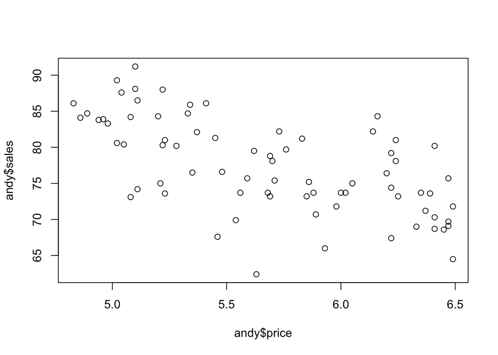

```r
plot(andy$price, andy$sales)
```

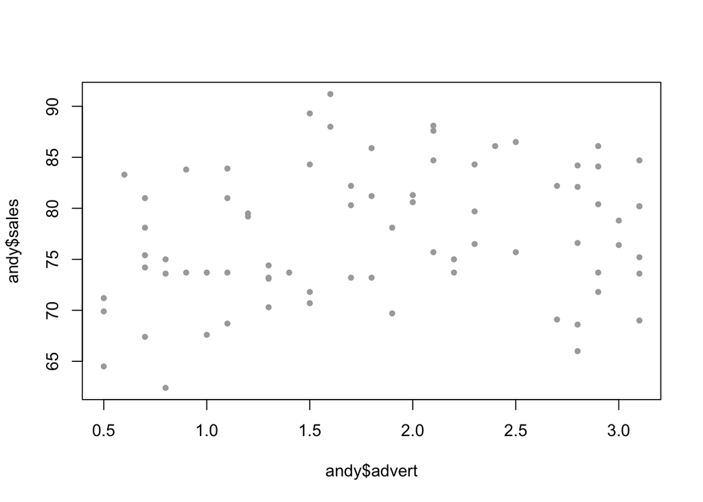

```r
plot(andy$advert, andy$sales, ylim = c(min(andy$sales), max(andy$sales)), pch = 20, col = "darkgray")
```

```r
library(xtable)
mod1 <- lm(sales~price+advert, data=andy)
library(knitr)
kable(summary(mod1) %>% xtable %>% data.frame)
```

|  | Estimate | Std..Error | t.value | Pr…t.. |
| --- | --- | --- | --- | --- |
| (Intercept) | 118.913610 | 6.3516375 | 18.721725 | 0.0000000 |
| price | -7.907854 | 1.0959930 | -7.215242 | 0.0000000 |
| advert | 1.862584 | 0.6831955 | 2.726283 | 0.0080382 |

```r
summary(mod1)
```

```
##
## Call:
## lm(formula = sales ~ price + advert, data = andy)
##
## Residuals:
##      Min       1Q   Median       3Q      Max
## -13.4825  -3.1434  -0.3456   2.8754  11.3049
##
## Coefficients:
##             Estimate Std. Error t value Pr(>|t|)
## (Intercept) 118.9136     6.3516  18.722  < 2e-16 ***
## price        -7.9079     1.0960  -7.215 4.42e-10 ***
## advert        1.8626     0.6832   2.726  0.00804 **
## ---
## Signif. codes:  0 '***' 0.001 '**' 0.01 '*' 0.05 '.' 0.1 ' ' 1
##
## Residual standard error: 4.886 on 72 degrees of freedom
## Multiple R-squared:  0.4483, Adjusted R-squared:  0.4329
## F-statistic: 29.25 on 2 and 72 DF,  p-value: 5.041e-10
```

```r
library(lmtest)
# Teste 1: normalidade dos resíduos
# estará tudo OK se eu não rejeitar a H0 de normalidade
shapiro.test(mod1$residuals)
```

```
##
##  Shapiro-Wilk normality test
##
## data:  mod1$residuals
## W = 0.98797, p-value = 0.7028
```

```r
# Teste 2: forma funcional (teste RESET de Ramsey)
# se aceitar H0 a forma funcional é adequada
reset(mod1)
```

```
##
##  RESET test
##
## data:  mod1
## RESET = 0.53369, df1 = 2, df2 = 70, p-value = 0.5888
```

```r
# Teste 3: heteroscedasticidade
# se não rejeitar H0 os resultados são homoscedásticos
bptest(mod1)
```

```
##
##  studentized Breusch-Pagan test
##
## data:  mod1
## BP = 2.5722, df = 2, p-value = 0.2763
```

```r
library(effects)
```

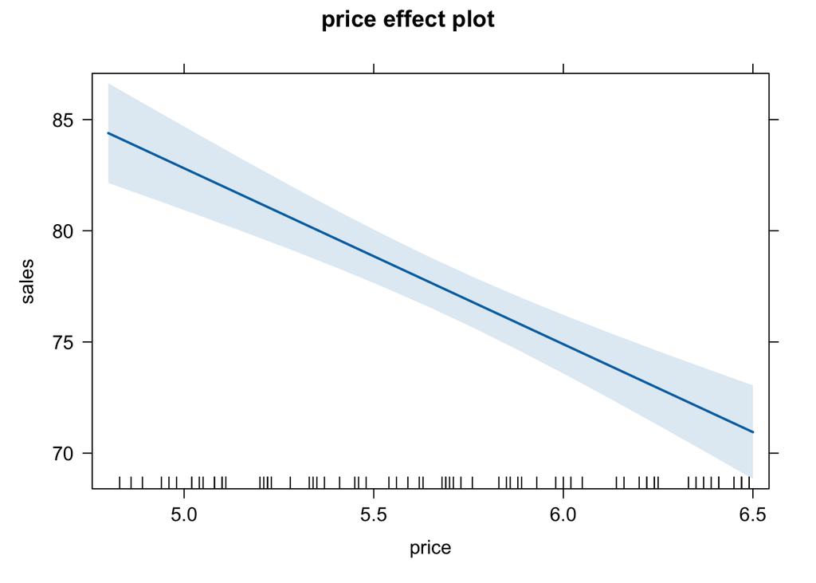

```r
effprice <- effect("price", mod1)
plot(effprice)
```

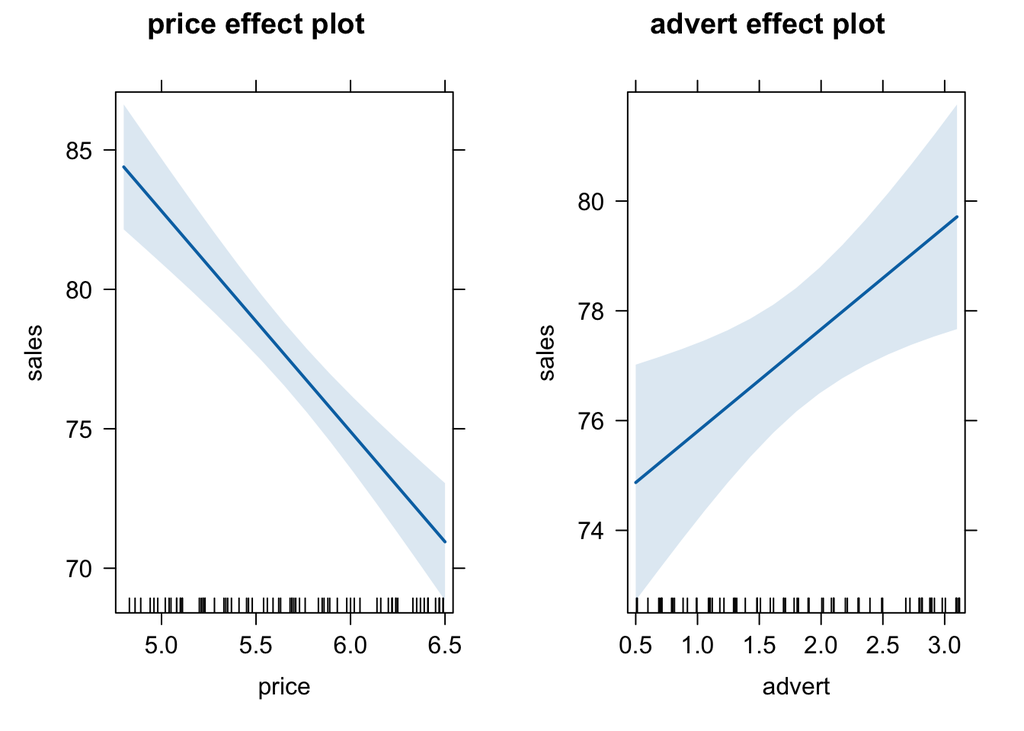

```r
alleffandy <- allEffects(mod1)
plot(alleffandy)
```

```r
mod2 <- lm(sales~price+advert+I(advert^2), data=andy)
summary(mod2)
```

```
##
## Call:
## lm(formula = sales ~ price + advert + I(advert^2), data = andy)
##
## Residuals:
##      Min       1Q   Median       3Q      Max
## -12.2553  -3.1430  -0.0117   2.8513  11.8050
##
## Coefficients:
##             Estimate Std. Error t value Pr(>|t|)
## (Intercept) 109.7190     6.7990  16.137  < 2e-16 ***
## price        -7.6400     1.0459  -7.304 3.24e-10 ***
## advert       12.1512     3.5562   3.417  0.00105 **
## I(advert^2)  -2.7680     0.9406  -2.943  0.00439 **
## ---
## Signif. codes:  0 '***' 0.001 '**' 0.01 '*' 0.05 '.' 0.1 ' ' 1
##
## Residual standard error: 4.645 on 71 degrees of freedom
## Multiple R-squared:  0.5082, Adjusted R-squared:  0.4875
## F-statistic: 24.46 on 3 and 71 DF,  p-value: 5.6e-11
```

```r
library(lmtest)
# Teste 1: normalidade dos resíduos
# estará tudo OK se eu não rejeitar a H0 de normalidade
shapiro.test(mod2$residuals)
```

```
##
##  Shapiro-Wilk normality test
##
## data:  mod2$residuals
## W = 0.98775, p-value = 0.6894
```

```r
# Teste 2: forma funcional (teste RESET de Ramsey)
# se aceitar H0 a forma funcional é adequada
reset(mod2)
```

```
##
##  RESET test
##
## data:  mod2
## RESET = 2.7695, df1 = 2, df2 = 69, p-value = 0.06967
```

```r
# Teste 3: heteroscedasticidade
# se não rejeitar H0 os resultados são homoscedásticos
bptest(mod1)
```

```
##
##  studentized Breusch-Pagan test
##
## data:  mod1
## BP = 2.5722, df = 2, p-value = 0.2763
```

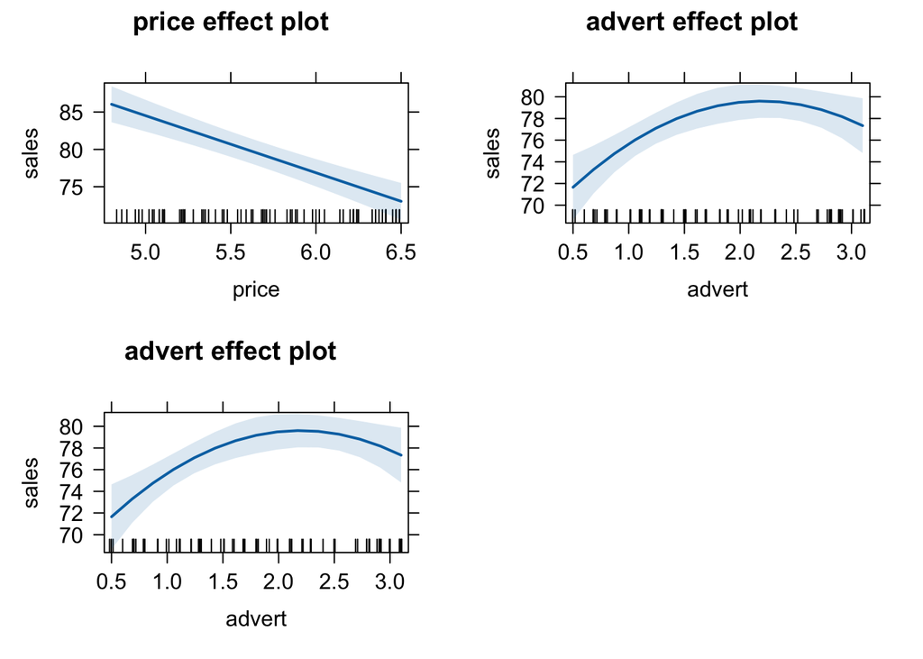

```r
alleffandy <- allEffects(mod2)
plot(alleffandy)
```

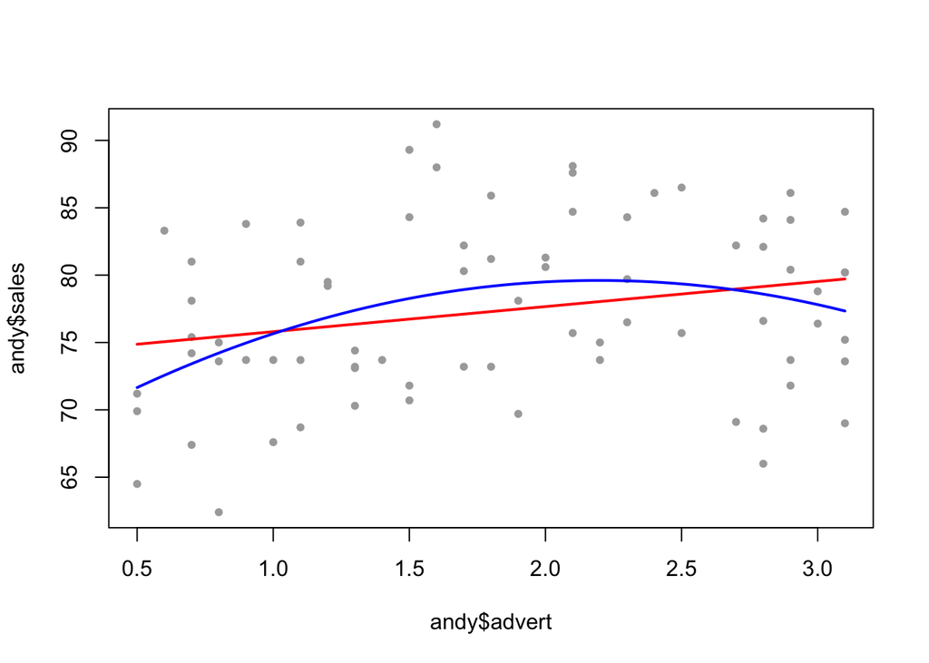

```r
plot(andy$advert, andy$sales, ylim = c(min(andy$sales), max(andy$sales)), pch = 20, col = "darkgray")
adv = seq(min(andy$advert), max(andy$advert), length.out = 100)
y = predict(mod1, data.frame(advert = adv, price = mean(andy$price)))
lines(adv, y, col = "red", lwd = 2)
y = predict(mod2, data.frame(advert = adv, price = mean(andy$price)))
lines(adv, y, col = "blue", lwd = 2)
```

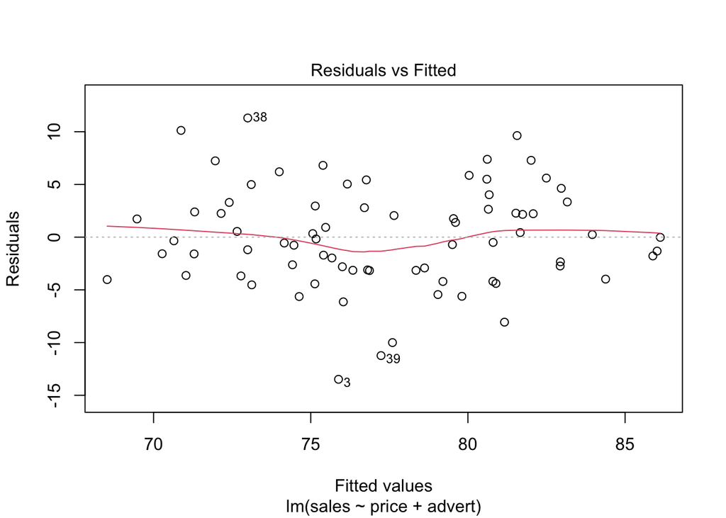

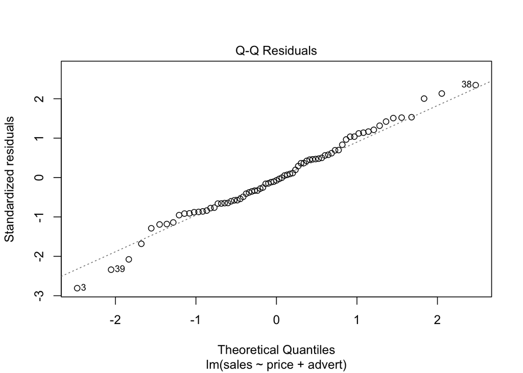

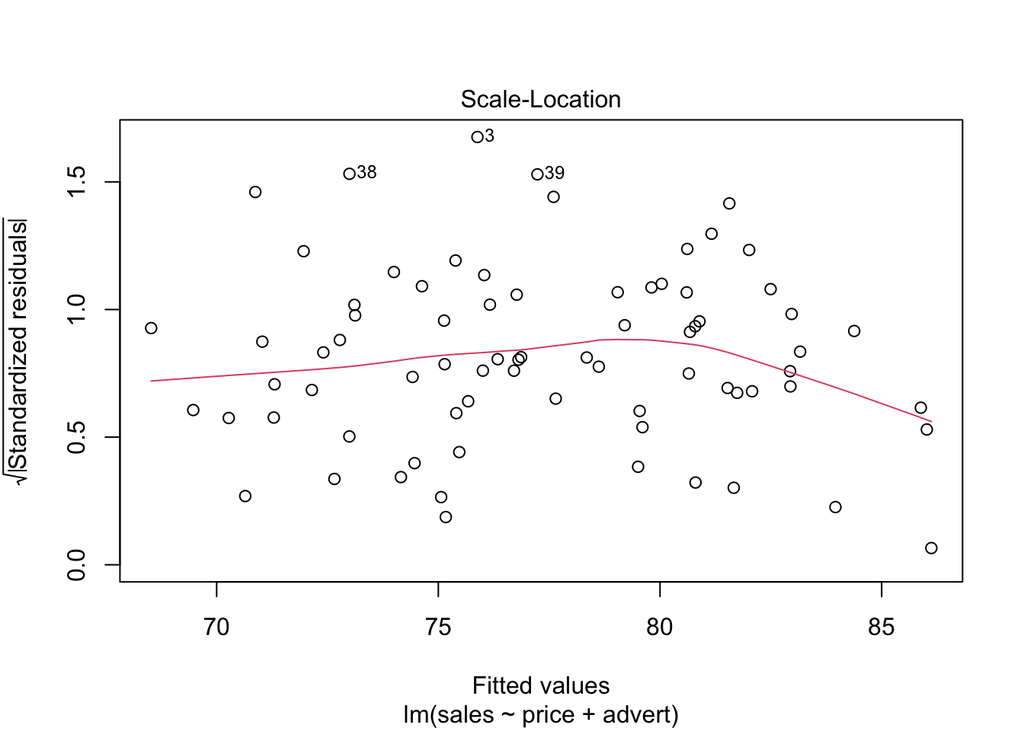

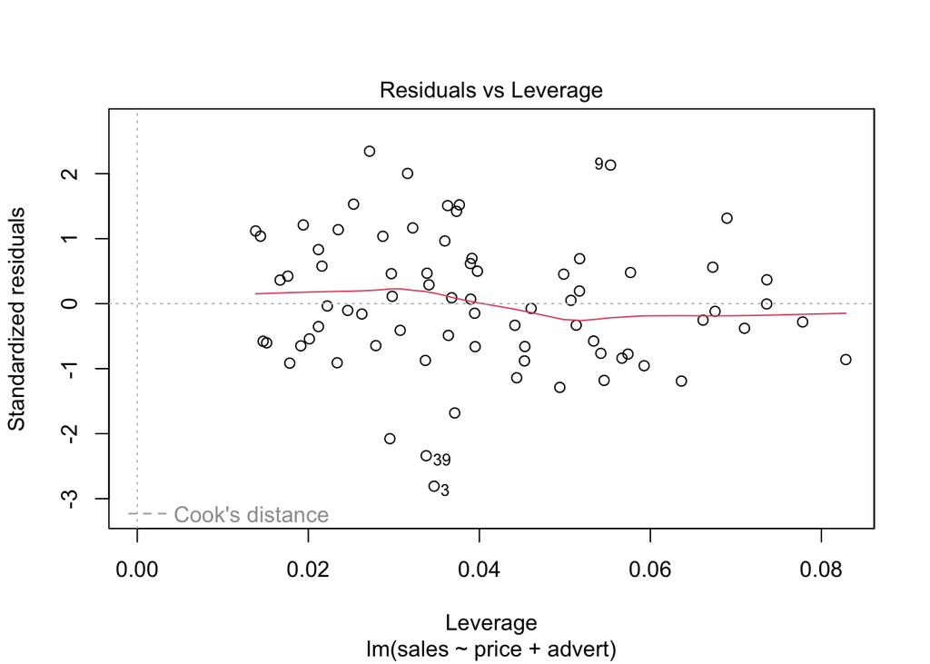

```r
plot(mod1)
```

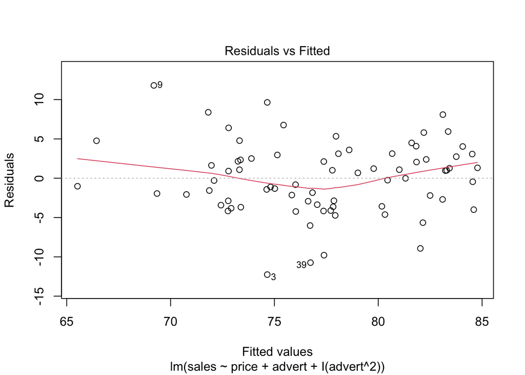

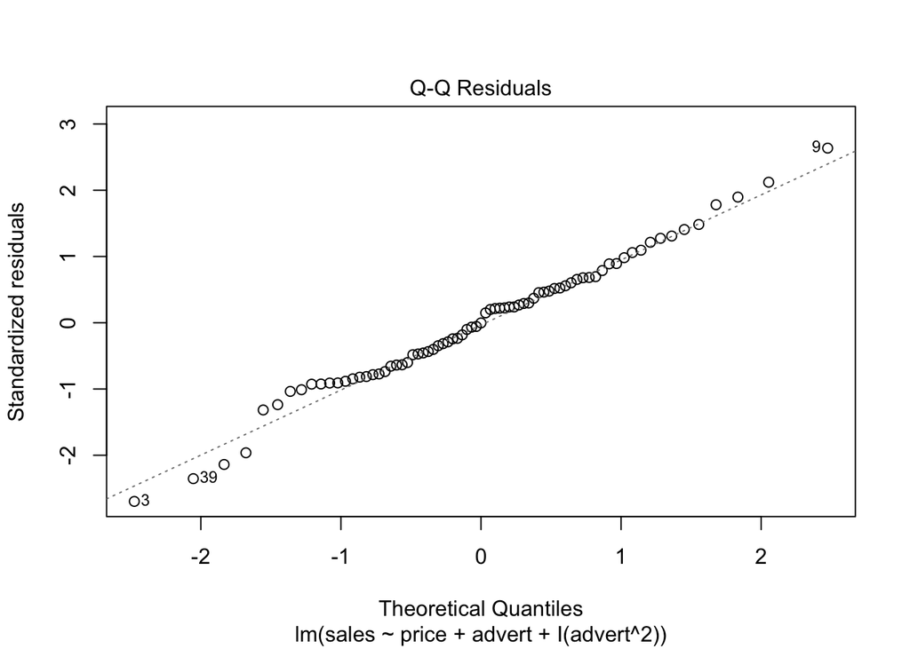

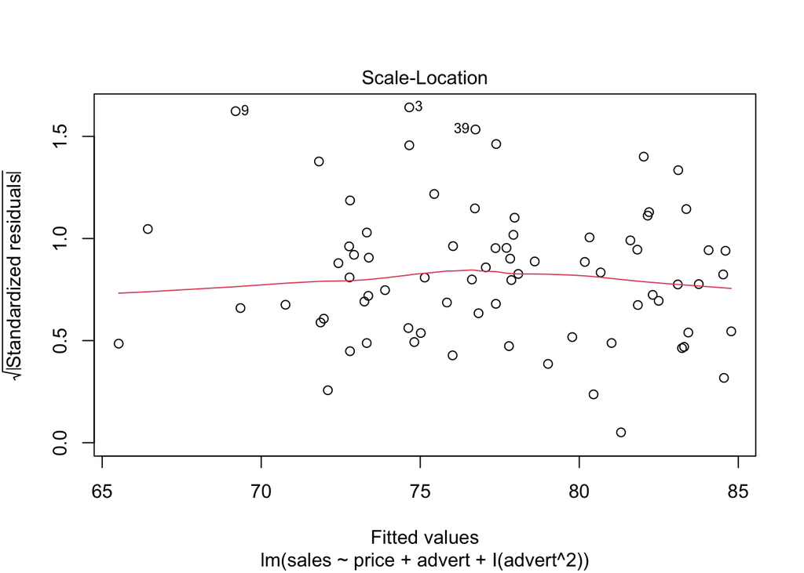

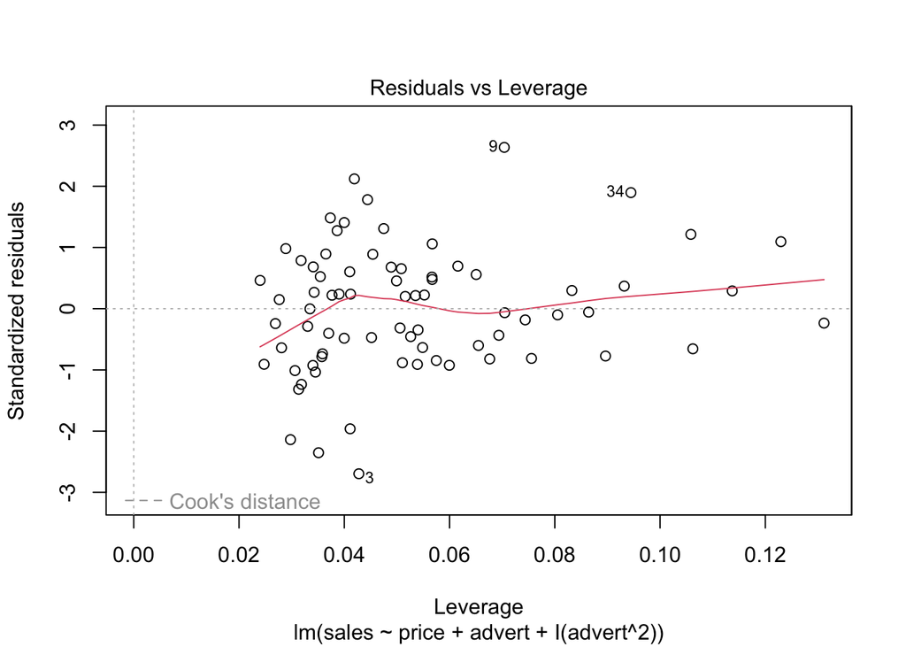

```r
plot(mod2)
```

Matrizes de covariância

```r
vcov(mod1)
```

```
##             (Intercept)       price      advert
## (Intercept)  40.3432990 -6.79506412 -0.74842060
## price        -6.7950641  1.20120070 -0.01974215
## advert       -0.7484206 -0.01974215  0.46675606
```

```r
vcov(mod2)
```

```
##             (Intercept)       price      advert I(advert^2)
## (Intercept)   46.227019 -6.42611301 -11.6009601  2.93902634
## price         -6.426113  1.09398815   0.3004062 -0.08561906
## advert       -11.600960  0.30040624  12.6463020 -3.28874574
## I(advert^2)    2.939026 -0.08561906  -3.2887457  0.88477357
```

```r
cbind(andy$sales, andy$price, andy$advert, andy$advert^2) %>% var
```

```
##           [,1]        [,2]       [,3]      [,4]
## [1,] 42.101106 -2.10423405 1.19842703 3.3387205
## [2,] -2.104234  0.26877178 0.01136811 0.0682647
## [3,]  1.198427  0.01136811 0.69168649 2.5721319
## [4,]  3.338721  0.06826470 2.57213189 9.8969231
```

Conseguimos comprovar as nossas hipóteses?

Conseguimos controlar as hipóteses alternativas?

$R^2_{aj}(mod1)=0.4329316$ e $R^2_{aj}(mod2)=0.4874564$

## 1.3 Distribuição t ou distribuição normal?

```r
qnorm(1-0.05/2) %>% round(4)
```

```
## [1] 1.96
```

```r
qt(1-0.05/2, 5000-2)
```

```
## [1] 1.960439
```

```r
qt(1-0.05/2, 500-2)
```

```
## [1] 1.964739
```

```r
qt(1-0.05/2, 200-2)
```

```
## [1] 1.972017
```

```r
qt(1-0.05/2, 120-2)
```

```
## [1] 1.980272
```

```r
qt(1-0.05/2, 30-2)
```

```
## [1] 2.048407
```

## 1.4 modelo polinomial do segundo grau para Andy

```r
mod2
```

```
##
## Call:
## lm(formula = sales ~ price + advert + I(advert^2), data = andy)
##
## Coefficients:
## (Intercept)        price       advert  I(advert^2)
##     109.719       -7.640       12.151       -2.768
```

Qual o valor máximo a ser investido em propaganda?

Fica perto do ponto onde a parábola atinge o seu máximo.

Ponto de máximo:

$$advert = \dfrac{-b}{2a} = \dfrac{-12.151}{2(-2.768)} = \dfrac{12.151}{5.536} \approx 2.194906$$

```r
12.151/(2*2.768)
```

```
## [1] 2.194906
```

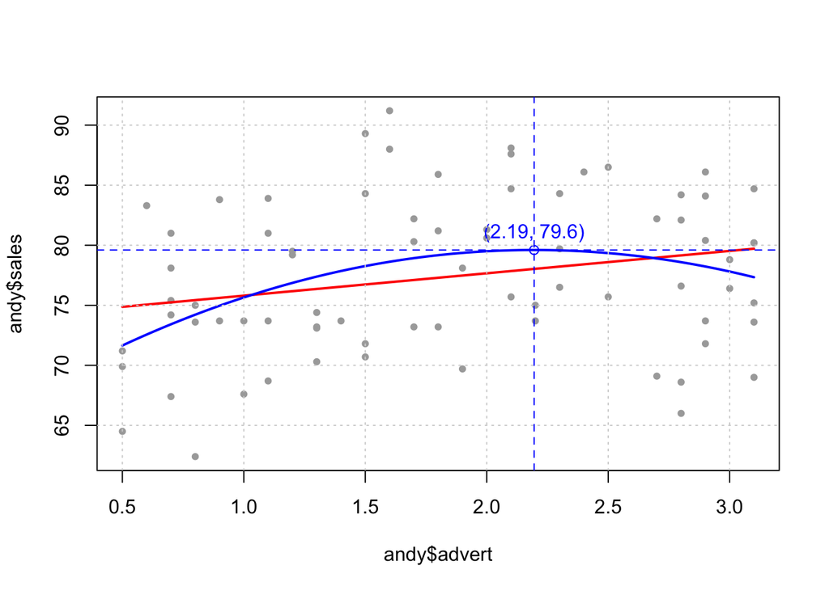

```r
plot(andy$advert, andy$sales, ylim = c(min(andy$sales), max(andy$sales)), pch = 20, col = "darkgray")
adv = seq(min(andy$advert), max(andy$advert), length.out = 100)
y = predict(mod1, data.frame(advert = adv, price = mean(andy$price)))
lines(adv, y, col = "red", lwd = 2)
y = predict(mod2, data.frame(advert = adv, price = mean(andy$price)))
lines(adv, y, col = "blue", lwd = 2)
xmax = 12.151/(2*2.768)
ymax = predict(mod2, data.frame(price = mean(andy$price), advert = xmax))
abline(v = xmax, h = ymax, lty = 2, col = "blue")
points(xmax, ymax, col = "blue")
text(xmax, ymax, paste("(", xmax %>% round(2), ", ", ymax %>% round(2), ")", sep = ""), pos = 3, col = "blue")
grid()
```

```r
mean(andy$price)
```

```
## [1] 5.6872
```

## 1.5 5.6 Interaction Terms in Linear Regression

```r
data("pizza4",package="PoEdata")
head(pizza4)
```

```
##   pizza female hs college grad income age
## 1   109      1  0       0    0   19.5  25
## 2     0      1  0       0    0   39.0  45
## 3     0      1  0       0    0   15.6  20
## 4   108      1  0       0    0   26.0  28
## 5   220      1  1       0    0   19.5  25
## 6   189      1  1       0    0   39.0  35
```

```r
?pizza4
```

```r
mod3 = lm(pizza~income, data = pizza4)
mod3 %>% summary
```

```
##
## Call:
## lm(formula = pizza ~ income, data = pizza4)
##
## Residuals:
##     Min      1Q  Median      3Q     Max
## -260.17 -103.81  -49.86  122.59  337.12
##
## Coefficients:
##             Estimate Std. Error t value Pr(>|t|)
## (Intercept) 128.9803    34.5913   3.729 0.000626 ***
## income        1.1213     0.4595   2.440 0.019461 *
## ---
## Signif. codes:  0 '***' 0.001 '**' 0.01 '*' 0.05 '.' 0.1 ' ' 1
##
## Residual standard error: 146.8 on 38 degrees of freedom
## Multiple R-squared:  0.1355, Adjusted R-squared:  0.1127
## F-statistic: 5.954 on 1 and 38 DF,  p-value: 0.01946
```

```r
mod3 = lm(pizza~age, data = pizza4)
mod3 %>% summary
```

```
##
## Call:
## lm(formula = pizza ~ age, data = pizza4)
##
## Residuals:
##     Min      1Q  Median      3Q     Max
## -235.90 -131.28  -18.39  107.80  393.60
##
## Coefficients:
##             Estimate Std. Error t value Pr(>|t|)
## (Intercept)  301.728     84.206   3.583 0.000951 ***
## age           -3.291      2.408  -1.367 0.179671
## ---
## Signif. codes:  0 '***' 0.001 '**' 0.01 '*' 0.05 '.' 0.1 ' ' 1
##
## Residual standard error: 154.2 on 38 degrees of freedom
## Multiple R-squared:  0.04687,    Adjusted R-squared:  0.02179
## F-statistic: 1.869 on 1 and 38 DF,  p-value: 0.1797
```

```r
mod3 = lm(pizza~age+income, data = pizza4)
mod3 %>% summary
```

```
##
## Call:
## lm(formula = pizza ~ age + income, data = pizza4)
##
## Residuals:
##     Min      1Q  Median      3Q     Max
## -219.96 -116.36   27.85   88.02  287.04
##
## Coefficients:
##             Estimate Std. Error t value Pr(>|t|)
## (Intercept) 342.8848    72.3434   4.740 3.14e-05 ***
## age          -7.5756     2.3170  -3.270 0.002333 **
## income        1.8325     0.4643   3.947 0.000341 ***
## ---
## Signif. codes:  0 '***' 0.001 '**' 0.01 '*' 0.05 '.' 0.1 ' ' 1
##
## Residual standard error: 131.1 on 37 degrees of freedom
## Multiple R-squared:  0.3293, Adjusted R-squared:  0.293
## F-statistic: 9.081 on 2 and 37 DF,  p-value: 0.0006185
```

```r
mod3 = lm(pizza~age+income+age:income, data = pizza4)
mod3 %>% summary
```

```
##
## Call:
## lm(formula = pizza ~ age + income + age:income, data = pizza4)
##
## Residuals:
##     Min      1Q  Median      3Q     Max
## -200.86  -83.82   20.70   85.04  254.23
##
## Coefficients:
##              Estimate Std. Error t value Pr(>|t|)
## (Intercept) 161.46543  120.66341   1.338   0.1892
## age          -2.97742    3.35210  -0.888   0.3803
## income        6.97991    2.82277   2.473   0.0183 *
## age:income   -0.12324    0.06672  -1.847   0.0730 .
## ---
## Signif. codes:  0 '***' 0.001 '**' 0.01 '*' 0.05 '.' 0.1 ' ' 1
##
## Residual standard error: 127 on 36 degrees of freedom
## Multiple R-squared:  0.3873, Adjusted R-squared:  0.3363
## F-statistic: 7.586 on 3 and 36 DF,  p-value: 0.0004681
```

```r
mod3 = lm(pizza~age+income+income:age, data = pizza4)
mod3 %>% summary
```

```
##
## Call:
## lm(formula = pizza ~ age + income + income:age, data = pizza4)
##
## Residuals:
##     Min      1Q  Median      3Q     Max
## -200.86  -83.82   20.70   85.04  254.23
##
## Coefficients:
##              Estimate Std. Error t value Pr(>|t|)
## (Intercept) 161.46543  120.66341   1.338   0.1892
## age          -2.97742    3.35210  -0.888   0.3803
## income        6.97991    2.82277   2.473   0.0183 *
## age:income   -0.12324    0.06672  -1.847   0.0730 .
## ---
## Signif. codes:  0 '***' 0.001 '**' 0.01 '*' 0.05 '.' 0.1 ' ' 1
##
## Residual standard error: 127 on 36 degrees of freedom
## Multiple R-squared:  0.3873, Adjusted R-squared:  0.3363
## F-statistic: 7.586 on 3 and 36 DF,  p-value: 0.0004681
```

```r
mod3 = lm(pizza~age*income, data = pizza4)
mod3 %>% summary
```

```
##
## Call:
## lm(formula = pizza ~ age * income, data = pizza4)
##
## Residuals:
##     Min      1Q  Median      3Q     Max
## -200.86  -83.82   20.70   85.04  254.23
##
## Coefficients:
##              Estimate Std. Error t value Pr(>|t|)
## (Intercept) 161.46543  120.66341   1.338   0.1892
## age          -2.97742    3.35210  -0.888   0.3803
## income        6.97991    2.82277   2.473   0.0183 *
## age:income   -0.12324    0.06672  -1.847   0.0730 .
## ---
## Signif. codes:  0 '***' 0.001 '**' 0.01 '*' 0.05 '.' 0.1 ' ' 1
##
## Residual standard error: 127 on 36 degrees of freedom
## Multiple R-squared:  0.3873, Adjusted R-squared:  0.3363
## F-statistic: 7.586 on 3 and 36 DF,  p-value: 0.0004681
```

```r
data(cps4_small)
head(cps4_small)
```

```
##    wage educ exper hrswk married female metro midwest south west black asian
## 1 18.70   16    39    37       1      1     1       0     1    0     0     0
## 2 11.50   12    16    62       0      0     0       1     0    0     0     0
## 3 15.04   16    13    40       1      0     1       0     0    1     1     0
## 4 25.95   14    11    40       0      1     1       0     1    0     1     0
## 5 24.03   12    51    40       1      0     1       0     0    0     0     0
## 6 20.00   12    30    40       1      0     1       0     0    0     0     0
```

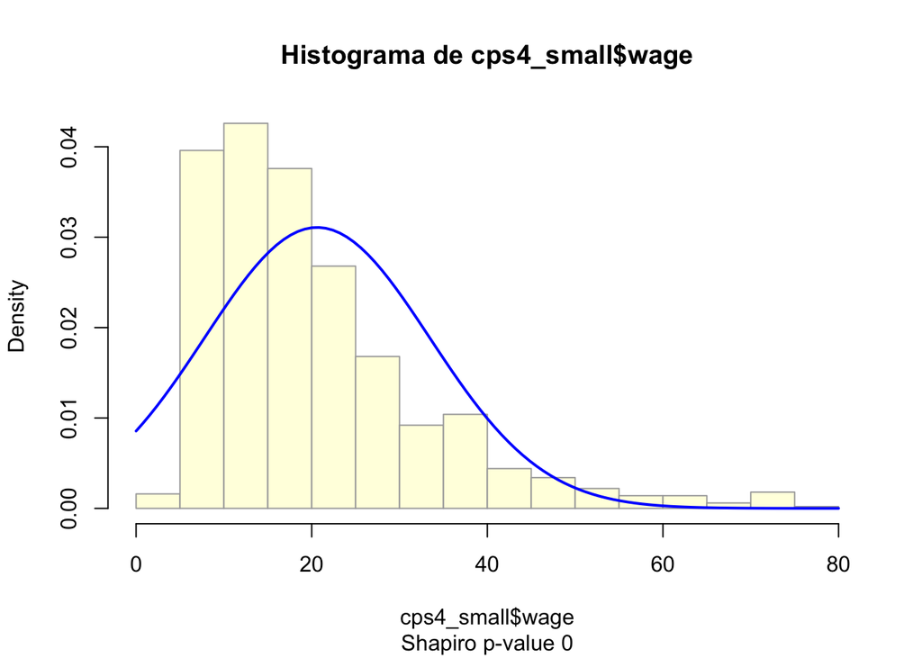

```r
# lembram da função mhist que foi definida no arquivo "Pequenos Experimentos.Rmd"?
# (dêem uma olhada lá)
# criei um arquivo que contém essa função (mhist.R) e para tornar essa funcionalidade
# disponível basta carregar o arquivo direto do github
source("https://raw.githubusercontent.com/jrfrega/2025/refs/heads/main/mhist.R")
# wage apresenta muitos outliers superiores
mhist(cps4_small$wage)
```

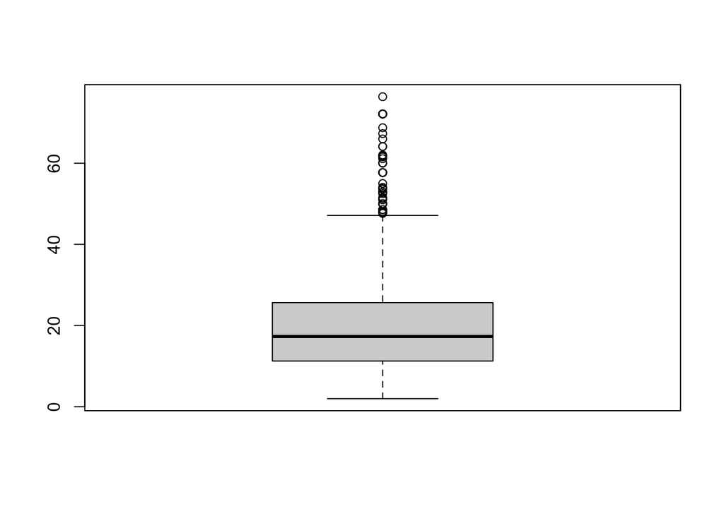

```r
boxplot(cps4_small$wage)
```

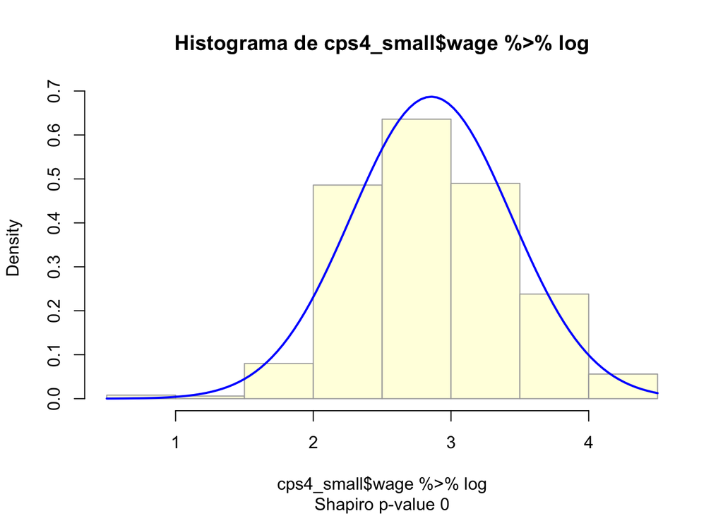

```r
# a transformação log reduz o problema a uns poucos outliers inferiores
mhist(cps4_small$wage %>% log)
```

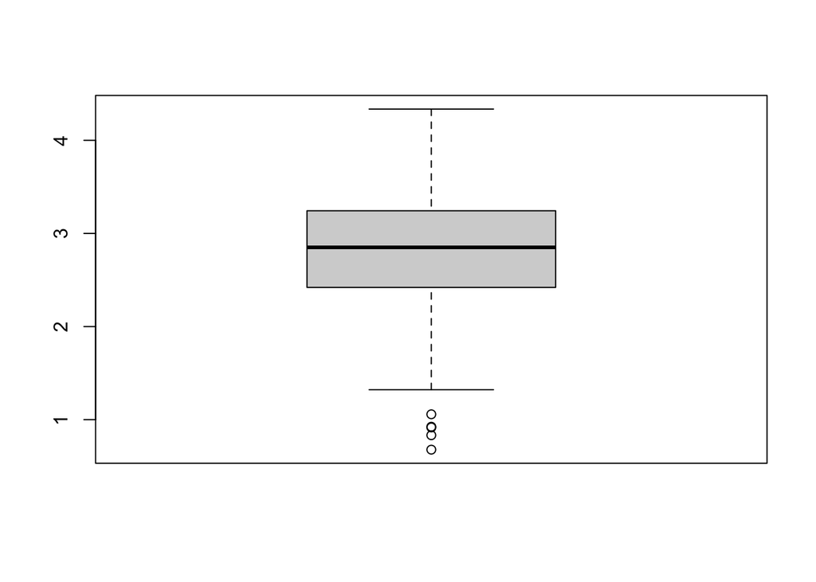

```r
boxplot(cps4_small$wage %>% log)
```

```r
# Lembrem de que qualquer modelo precisa ser suportado pela adequada teoria
# aqui está sendo proposta uma interação entre educ e exper
# e uma utilidade decrescente da exper
mod4 = lm(log(wage)~educ*exper+I(exper^2), data = cps4_small)
summary(mod4)
```

```
##
## Call:
## lm(formula = log(wage) ~ educ * exper + I(exper^2), data = cps4_small)
##
## Residuals:
##      Min       1Q   Median       3Q      Max
## -2.28227 -0.32856 -0.02725  0.33751  1.47088
##
## Coefficients:
##               Estimate Std. Error t value Pr(>|t|)
## (Intercept)  5.297e-01  2.267e-01   2.336  0.01969 *
## educ         1.272e-01  1.472e-02   8.642  < 2e-16 ***
## exper        6.298e-02  9.536e-03   6.604 6.48e-11 ***
## I(exper^2)  -7.139e-04  8.804e-05  -8.109 1.49e-15 ***
## educ:exper  -1.322e-03  4.949e-04  -2.672  0.00766 **
## ---
## Signif. codes:  0 '***' 0.001 '**' 0.01 '*' 0.05 '.' 0.1 ' ' 1
##
## Residual standard error: 0.5057 on 995 degrees of freedom
## Multiple R-squared:  0.2445, Adjusted R-squared:  0.2415
## F-statistic: 80.52 on 4 and 995 DF,  p-value: < 2.2e-16
```

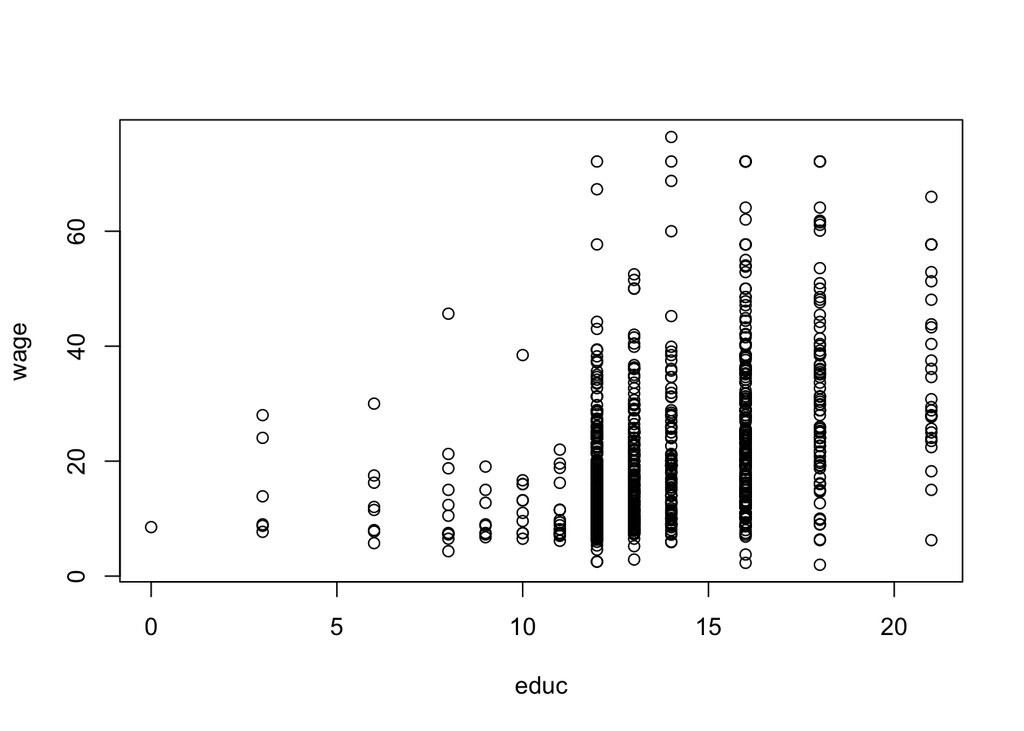

```r
with(cps4_small, plot(educ, wage))
```

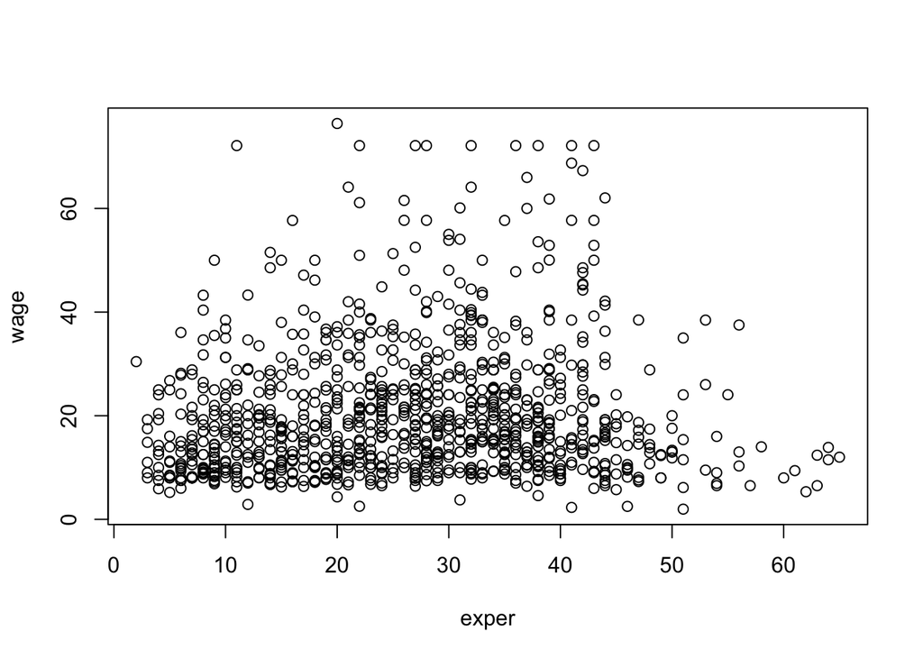

```r
with(cps4_small, plot(exper, wage))
```

# 2 Chapter 6 Further Inference in Multiple Regression

Necessidade de indicadores mais robustos que o $R^2$ para determinar a qualidade de uma regressão.

Modernamente, usa-se os critérios de informação

AIC (Akaike Information Criterion)

BIC (Bayesian Information Criterion)

```r
library(broom)
mod1
```

```
##
## Call:
## lm(formula = sales ~ price + advert, data = andy)
##
## Coefficients:
## (Intercept)        price       advert
##     118.914       -7.908        1.863
```

```r
mod2
```

```
##
## Call:
## lm(formula = sales ~ price + advert + I(advert^2), data = andy)
##
## Coefficients:
## (Intercept)        price       advert  I(advert^2)
##     109.719       -7.640       12.151       -2.768
```

```r
rbind(glance(mod1),
glance(mod2))
```

```
## # A tibble: 2 × 12
##   r.squared adj.r.squared sigma statistic  p.value    df logLik   AIC   BIC
##       <dbl>         <dbl> <dbl>     <dbl>    <dbl> <dbl>  <dbl> <dbl> <dbl>
## 1     0.448         0.433  4.89      29.2 5.04e-10     2  -224.  456.  465.
## 2     0.508         0.487  4.65      24.5 5.60e-11     3  -220.  449.  461.
## # ℹ 3 more variables: deviance <dbl>, df.residual <int>, nobs <int>
```

O melhor modelo é o que apresenta o menor valor para um dado critério de informação.

Com base no AIC, o modelo 1 (mod1) é pior que o modelo 2 (mod2) (455.739 > 449.108)

Os critérios de informação balanceiam a parcimônia do modelo com a qualidade do ajuste.

```r
mod1$call
```

```
## lm(formula = sales ~ price + advert, data = andy)
```

```r
mod2.1 = lm(formula = sales ~ price + advert + I(advert^2) + I(price^2), data = andy)
rbind(glance(mod1),
glance(mod2), glance(mod2.1))
```

```
## # A tibble: 3 × 12
##   r.squared adj.r.squared sigma statistic  p.value    df logLik   AIC   BIC
##       <dbl>         <dbl> <dbl>     <dbl>    <dbl> <dbl>  <dbl> <dbl> <dbl>
## 1     0.448         0.433  4.89      29.2 5.04e-10     2  -224.  456.  465.
## 2     0.508         0.487  4.65      24.5 5.60e-11     3  -220.  449.  461.
## 3     0.528         0.501  4.58      19.6 7.55e-11     4  -218.  448.  462.
## # ℹ 3 more variables: deviance <dbl>, df.residual <int>, nobs <int>
```

```r
mod2.2 = lm(formula = sales ~ price + advert + I(advert^2) + I(advert^3) + I(price^2), data = andy)
rbind(glance(mod1),
glance(mod2), glance(mod2.1), glance(mod2.2)) %>% as.data.frame -> df
row.names(df) = c("mod1 (linear)", "mod2 (quadrático em advert)", "mod2.1 (quadrático em tudo)", "mod2.2 (quadrático em price, cúbico em advert")
df[, c("adj.r.squared", "AIC", "BIC")]
```

```
##                                               adj.r.squared      AIC      BIC
## mod1 (linear)                                     0.4329316 455.7390 465.0090
## mod2 (quadrático em advert)                       0.4874564 449.1080 460.6954
## mod2.1 (quadrático em tudo)                       0.5010102 448.0341 461.9391
## mod2.2 (quadrático em price, cúbico em advert     0.4938355 450.0257 466.2481
```

```r
summary(mod2.1)
```

```
##
## Call:
## lm(formula = sales ~ price + advert + I(advert^2) + I(price^2),
##     data = andy)
##
## Residuals:
##      Min       1Q   Median       3Q      Max
## -11.1771  -2.9378   0.0949   2.8897  11.6856
##
## Coefficients:
##             Estimate Std. Error t value Pr(>|t|)
## (Intercept) 248.8390    81.5712   3.051 0.003225 **
## price       -57.0629    28.8988  -1.975 0.052262 .
## advert       13.1624     3.5582   3.699 0.000427 ***
## I(advert^2)  -3.0896     0.9469  -3.263 0.001708 **
## I(price^2)    4.3364     2.5340   1.711 0.091454 .
## ---
## Signif. codes:  0 '***' 0.001 '**' 0.01 '*' 0.05 '.' 0.1 ' ' 1
##
## Residual standard error: 4.583 on 70 degrees of freedom
## Multiple R-squared:  0.528,  Adjusted R-squared:  0.501
## F-statistic: 19.57 on 4 and 70 DF,  p-value: 7.553e-11
```

Pelo critério Akaike (AIC), o melhor modelo é mod2.1 (quadrático em tudo).

Pelo critério de Schwarz (AIC), o melhor modelo é mod2 (quadrático em advert).

Olhando o melhor modelo indicado pelo AIC,

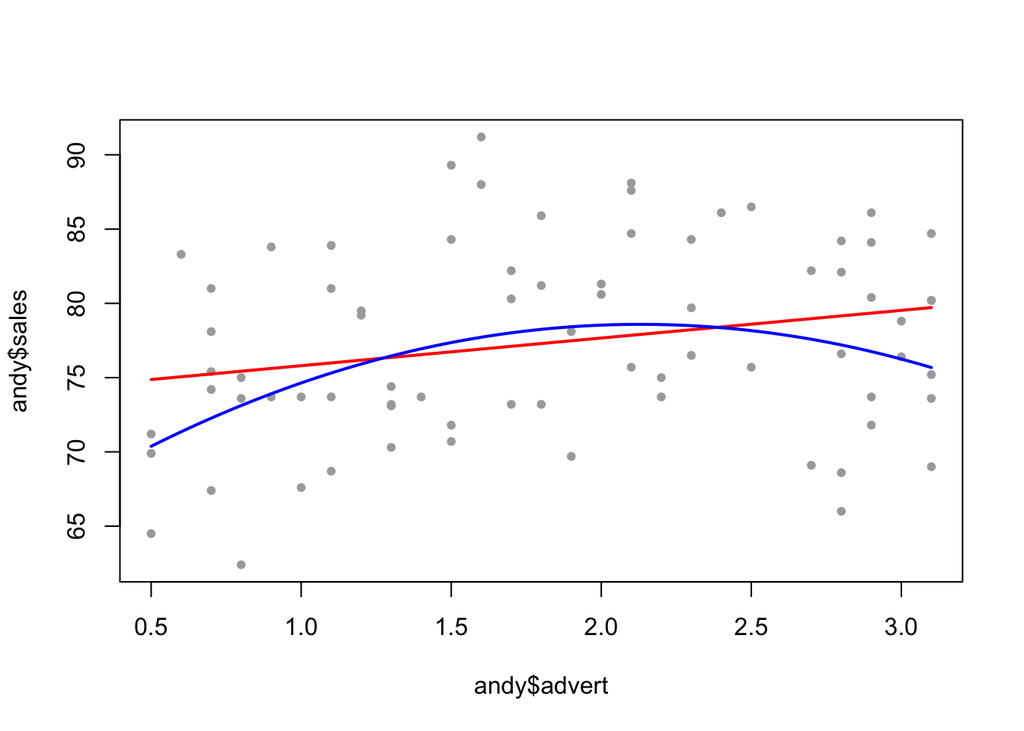

```r
plot(andy$advert, andy$sales, ylim = c(min(andy$sales), max(andy$sales)), pch = 20, col = "darkgray")
adv = seq(min(andy$advert), max(andy$advert), length.out = 100)
y = predict(mod1, data.frame(advert = adv, price = mean(andy$price)))
lines(adv, y, col = "red", lwd = 2)
y = predict(mod2.1, data.frame(advert = adv, price = mean(andy$price)))
lines(adv, y, col = "blue", lwd = 2)
```

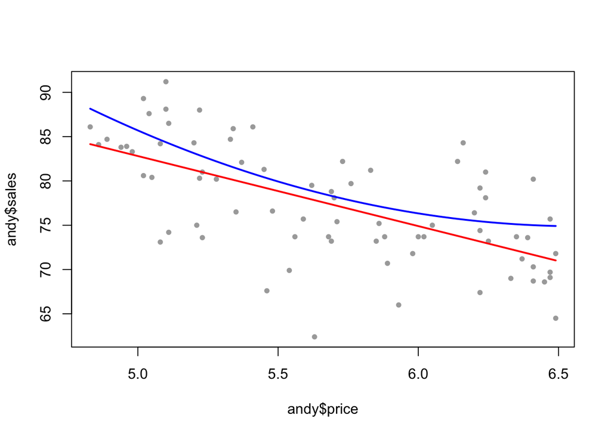

```r
plot(andy$price, andy$sales, ylim = c(min(andy$sales), max(andy$sales)), pch = 20, col = "darkgray")
prc = seq(min(andy$price), max(andy$price), length.out = 100)
y = predict(mod1, data.frame(advert = mean(andy$advert), price = prc))
lines(prc, y, col = "red", lwd = 2)
y = predict(mod2.1, data.frame(advert = mean(andy$advert), price = prc))
lines(prc, y, col = "blue", lwd = 2)
```

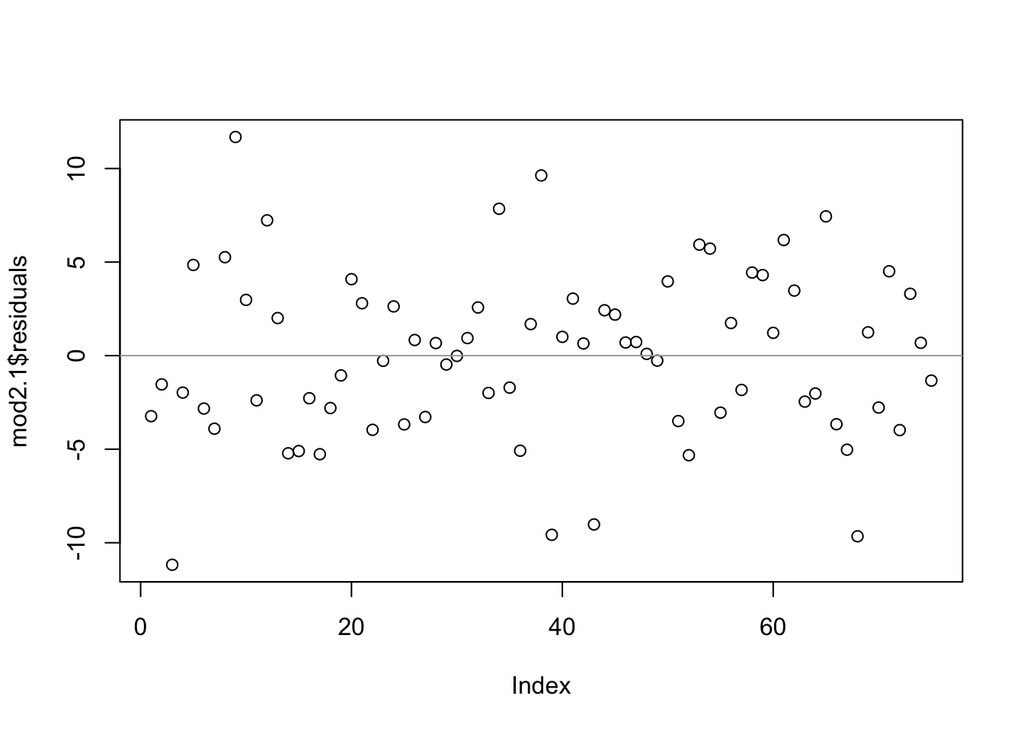

```r
plot(mod2.1$residuals); abline(h = 0, col = "darkgray")
```

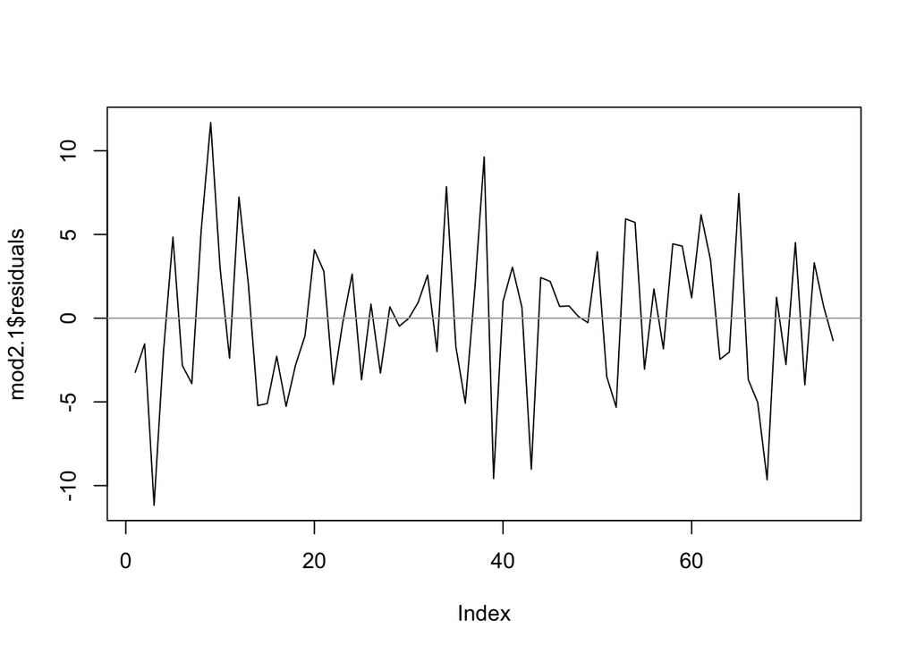

```r
plot(mod2.1$residuals, type = "l"); abline(h = 0, col = "darkgray")
```

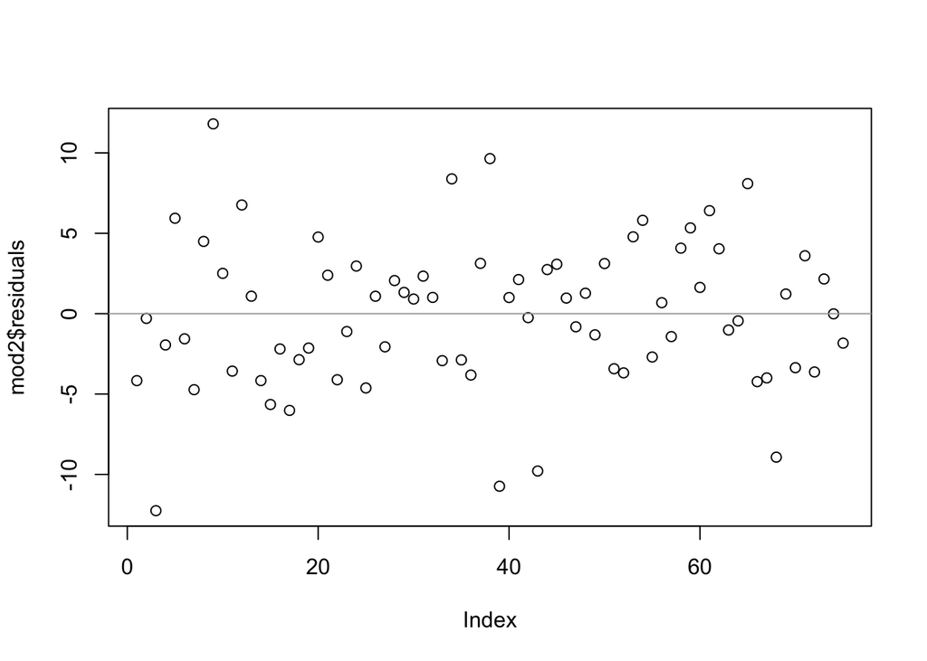

```r
plot(mod2$residuals); abline(h = 0, col = "darkgray")
```

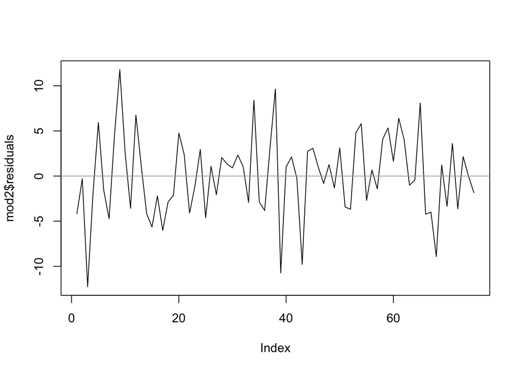

```r
plot(mod2$residuals, type = "l"); abline(h = 0, col = "darkgray")
```

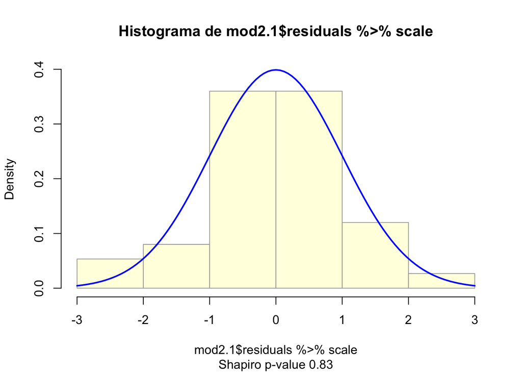

```r
mhist(mod2.1$residuals %>% scale, breaks = 6)
```